# wineQualityWhites_EDA

# Bivariate Plots Section

```
##                      fixed.acidity volatile.acidity  citric.acid
## fixed.acidity           1.00000000      -0.02269729  0.289180698
## volatile.acidity       -0.02269729       1.00000000 -0.149471811
## citric.acid             0.28918070      -0.14947181  1.000000000
## residual.sugar          0.08902070       0.06428606  0.094211624
## chlorides               0.02308564       0.07051157  0.114364448
## free.sulfur.dioxide    -0.04939586      -0.09701194  0.094077221
## total.sulfur.dioxide    0.09106976       0.08926050  0.121130798
## density                 0.26533101       0.02711385  0.149502571
## pH                     -0.42585829      -0.03191537 -0.163748211
## sulphates              -0.01714299      -0.03572815  0.062330940
## alcohol                -0.12088112       0.06771794 -0.075728730
## quality                -0.11366283      -0.19472297 -0.009209091
## acid                    0.98717874       0.07157062  0.394143356
## acid_nor                0.85092911       0.50583144  0.170986037
## sugar_acid              0.11208572      -0.10530887  0.022546906
##                      residual.sugar   chlorides free.sulfur.dioxide
## fixed.acidity            0.08902070  0.02308564       -0.0493958591
## volatile.acidity         0.06428606  0.07051157       -0.0970119393
## citric.acid              0.09421162  0.11436445        0.0940772210
## residual.sugar           1.00000000  0.08868454        0.2990983537
## chlorides                0.08868454  1.00000000        0.1013923521
## free.sulfur.dioxide      0.29909835  0.10139235        1.0000000000
## total.sulfur.dioxide     0.40143931  0.19891030        0.6155009650
## density                  0.83896645  0.25721132        0.2942104109
## pH                      -0.19413345 -0.09043946       -0.0006177961
## sulphates               -0.02666437  0.01676288        0.0592172458
## alcohol                 -0.45063122 -0.36018871       -0.2501039415
## quality                 -0.09757683 -0.20993441        0.0081580671
## acid                     0.10473749  0.04552987       -0.0451333172
## acid_nor                 0.11058884  0.05696746       -0.0935930610
## sugar_acid              -0.76428950 -0.04688074       -0.2888136640
##                      total.sulfur.dioxide     density            pH
## fixed.acidity                 0.091069756  0.26533101 -0.4258582910
## volatile.acidity              0.089260504  0.02711385 -0.0319153683
## citric.acid                   0.121130798  0.14950257 -0.1637482114
## residual.sugar                0.401439311  0.83896645 -0.1941334540
## chlorides                     0.198910300  0.25721132 -0.0904394560
## free.sulfur.dioxide           0.615500965  0.29421041 -0.0006177961
## total.sulfur.dioxide          1.000000000  0.52988132  0.0023209718
```

[output cut: 25 more lines]

```
## fixed.acidity         0.85092911  0.1120857243
## volatile.acidity      0.50583144 -0.1053088681
## citric.acid           0.17098604  0.0225469064
## residual.sugar        0.11058884 -0.7642895014
## chlorides             0.05696746 -0.0468807358
## free.sulfur.dioxide  -0.09359306 -0.2888136640
## total.sulfur.dioxide  0.12547885 -0.3690388081
## density               0.24318814 -0.5716487284
## pH                   -0.38422264  0.0548562103
## sulphates            -0.03356404 -0.0008598056
## alcohol              -0.06872275  0.2583226123
## quality              -0.20038504 -0.0132640236
## acid                  0.88939608  0.0976389289
## acid_nor              1.00000000  0.0413827320
## sugar_acid            0.04138273  1.0000000000
```

看起来酒的质量与酒精含量、密度的关系比较大，氯化物和挥发性酸性物质的量也在一定程度上影响了酒的质量 密度和剩余糖分的含量有比较大的关系； 游离的二氧化硫和总的二氧化硫的含量有一定的相对关系，这本身就是可以被预料到的； 密度和酒精含量也有一定的相对关系；

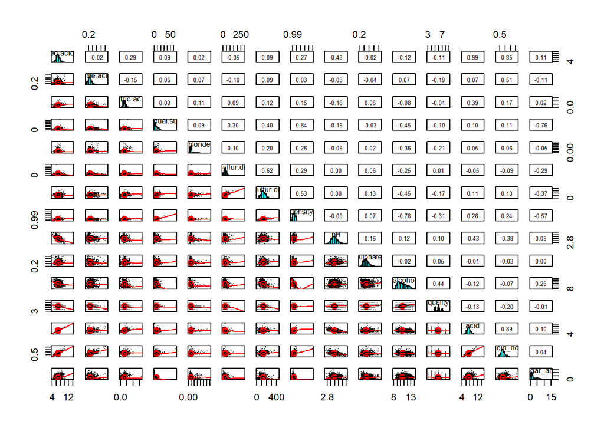

首先来探索与酒的质量相关性比较大的两个变量酒精含量和密度

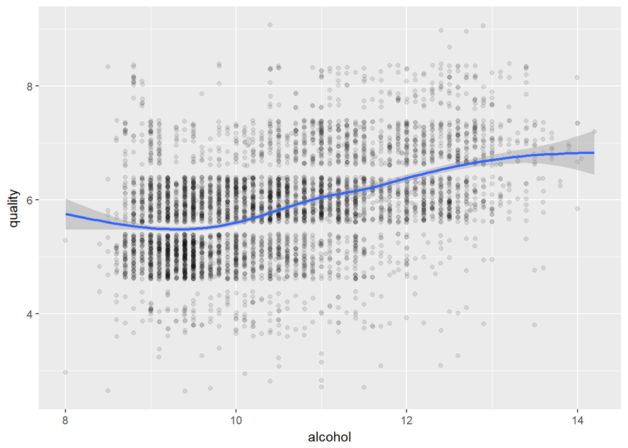

大体可以看出酒精含量与酒的质量是成正相关的关系，不过看起来不是很明显，我们将x轴与y轴进行互换，并画出箱线图

[figure not shown]

这下可以看出酒精含量和酒的质量并不是线性相关的，但很明显在质量比较高的酒中，酒精含量比较高的占的比重要大一些

[output not shown]

在单变量处理阶段，我们看到密度这一变量有异常值的存在，因此我们抛弃密度的后百分之一的值，画出箱线图

以酒的质量的数值对数据进行分组

```
## # A tibble: 6 x 6
##   quality mean_density median_density min_price mxa_price     n
##    <fctr>        <dbl>          <dbl>     <dbl>     <dbl> <int>
## 1       3    0.9948840       0.994425   0.99110   1.00010    20
## 2       4    0.9942767       0.994100   0.98920   1.00040   163
## 3       5    0.9952626       0.995300   0.98722   1.00241  1457
## 4       6    0.9939613       0.993660   0.98758   1.03898  2198
## 5       7    0.9924524       0.991760   0.98711   1.00040   880
## 6       8    0.9922359       0.991640   0.98713   1.00060   175
```

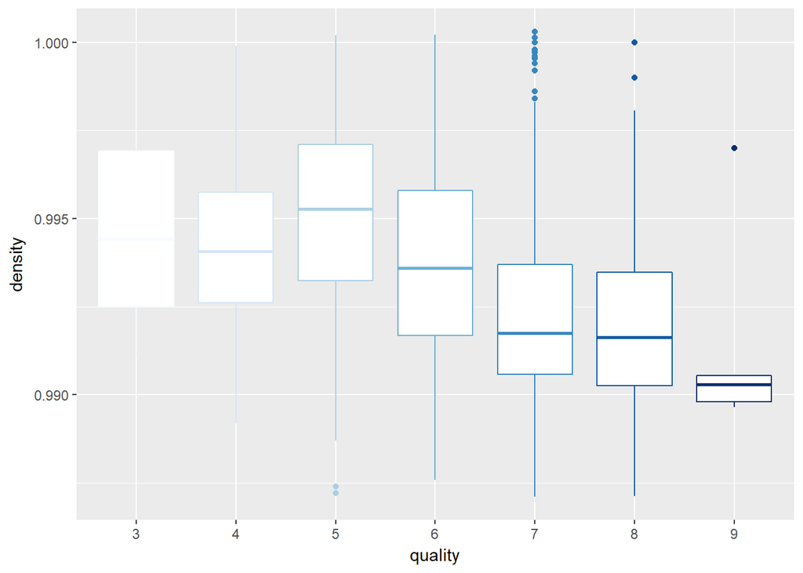

结论是质量越高的酒，酒的密度要更小一些 并且质量越高的酒，其酒精含量也越高一些 下面探索酒的密度和酒精含量这两个变量，看是否大体成相反的关系

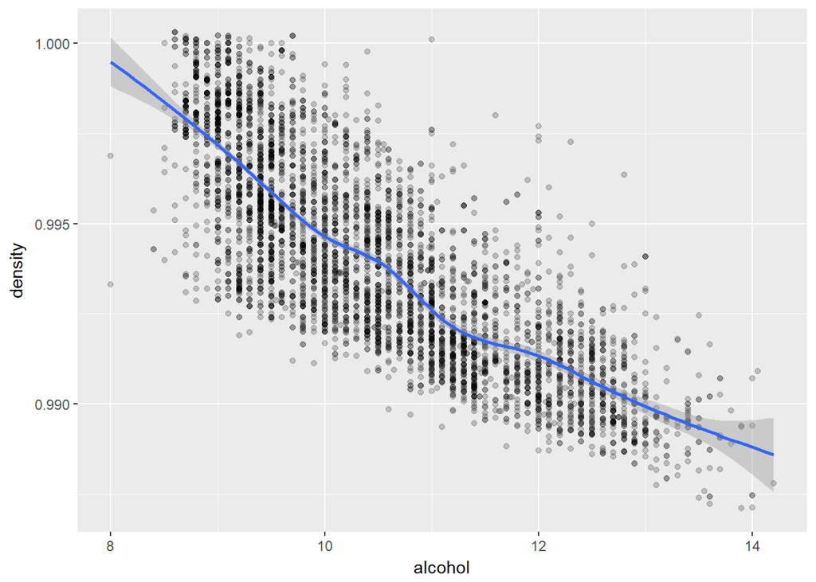

果然，白葡萄酒的酒精含量与酒的密度大体呈现处反比例关系，因为酒精的密度要比水小一些

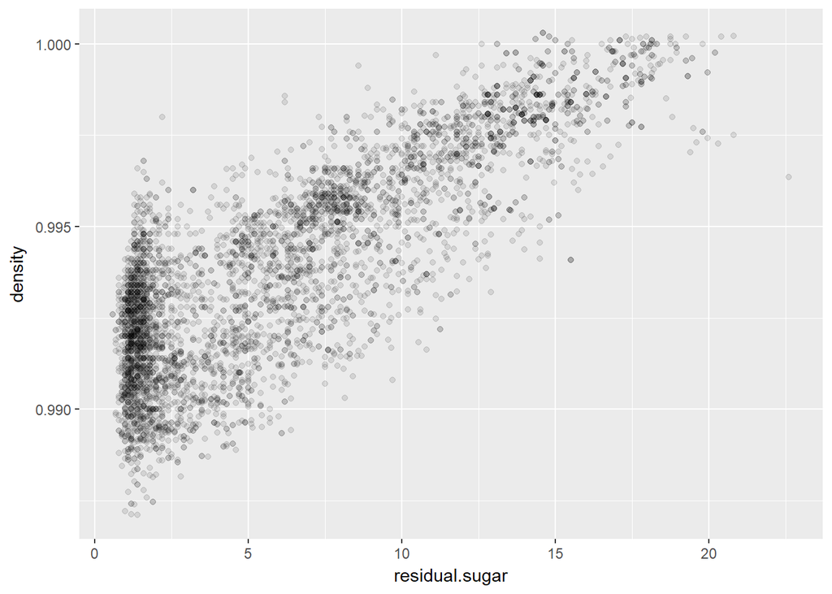

```
##
## Call:
## lm(formula = density ~ residual.sugar, data = wine)
##
## Coefficients:
##    (Intercept)  residual.sugar
##      0.9908654       0.0004947
```

剩余糖分与密度之间也是成正的相关关系，除了在糖分大约为1的地方，有大量的数据堆积

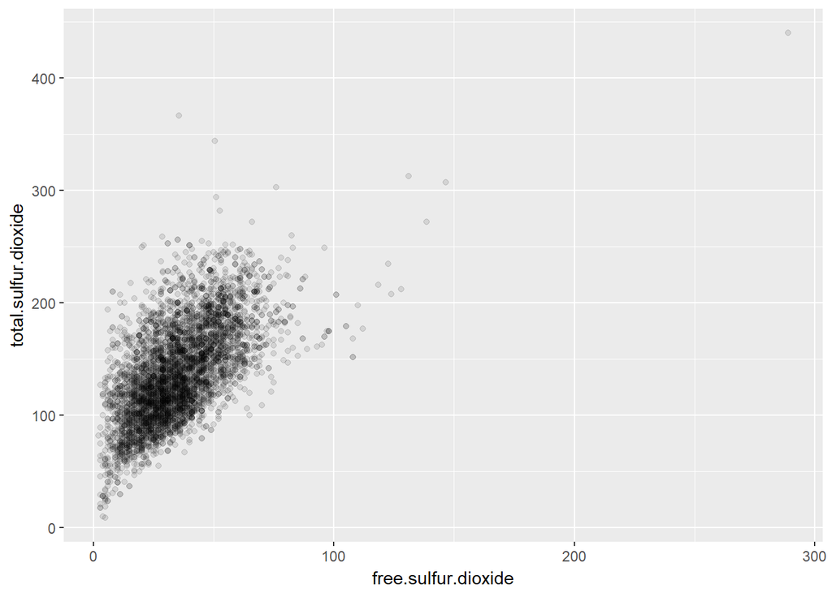

缩小横轴的范围

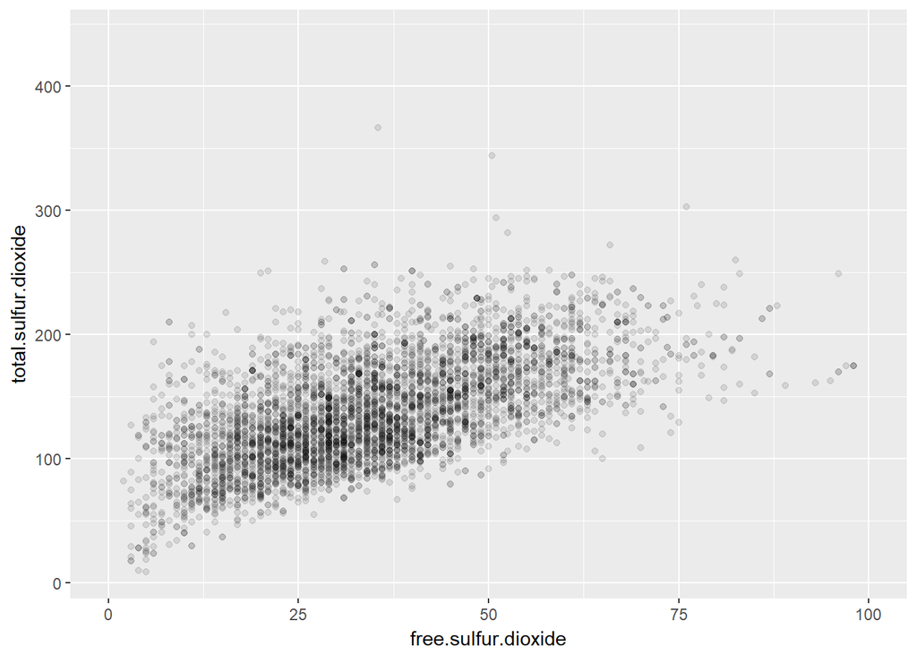

游离的二氧化硫的含量与总的二氧化硫的含量大体是呈现处正相关的关系，为了进一步确认，我们描绘游离的二氧化硫占总的二氧化硫的比重

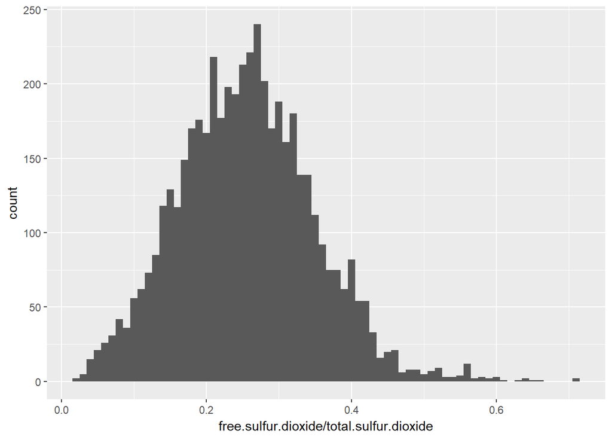

比重呈现出正态分布的形式，若将比重视为一个变量特征，查看其对酒的质量的影响

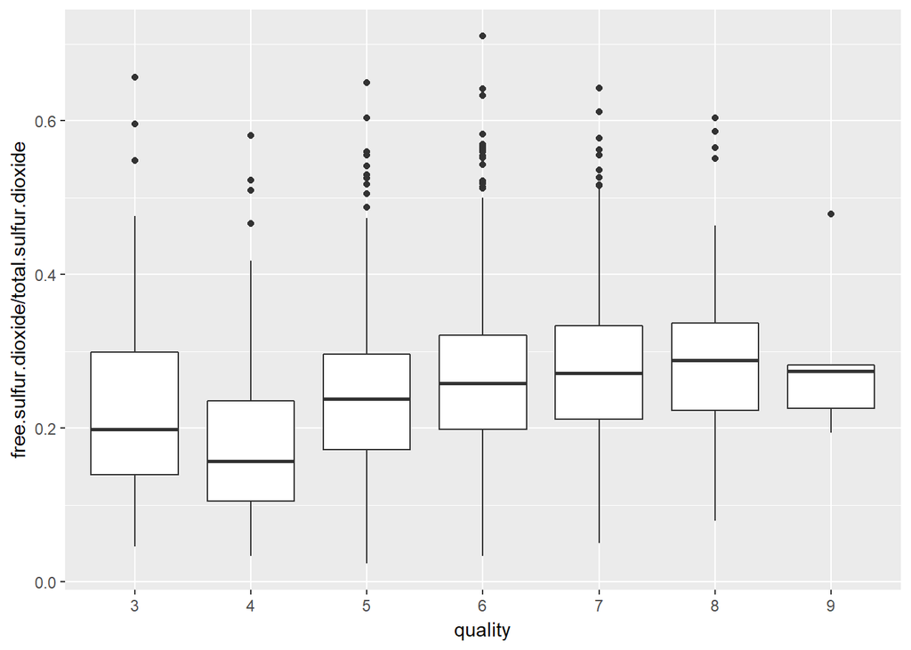

```
##
##  Pearson's product-moment correlation
##
## data:  wine$quality and wine$sulfur
## t = 14.076, df = 4896, p-value < 2.2e-16
## alternative hypothesis: true correlation is not equal to 0
## 95 percent confidence interval:
##  0.1701474 0.2239834
## sample estimates:
##       cor
## 0.1972141
```

相关系数达到了0.197，比之前单独的游离的二氧化硫含量和总的二氧化硫的含量对酒的质量的相关性都要高一些

```
##                      fixed.acidity volatile.acidity  citric.acid
## fixed.acidity           1.00000000      -0.02269729  0.289180698
## volatile.acidity       -0.02269729       1.00000000 -0.149471811
## citric.acid             0.28918070      -0.14947181  1.000000000
## residual.sugar          0.08902070       0.06428606  0.094211624
## chlorides               0.02308564       0.07051157  0.114364448
## free.sulfur.dioxide    -0.04939586      -0.09701194  0.094077221
## total.sulfur.dioxide    0.09106976       0.08926050  0.121130798
## density                 0.26533101       0.02711385  0.149502571
## pH                     -0.42585829      -0.03191537 -0.163748211
## sulphates              -0.01714299      -0.03572815  0.062330940
## alcohol                -0.12088112       0.06771794 -0.075728730
## quality                -0.11366283      -0.19472297 -0.009209091
## acid                    0.98717874       0.07157062  0.394143356
## acid_nor                0.85092911       0.50583144  0.170986037
## sugar_acid              0.11208572      -0.10530887  0.022546906
## sulfur                 -0.13945918      -0.19616085  0.016241396
##                      residual.sugar   chlorides free.sulfur.dioxide
## fixed.acidity            0.08902070  0.02308564       -0.0493958591
## volatile.acidity         0.06428606  0.07051157       -0.0970119393
## citric.acid              0.09421162  0.11436445        0.0940772210
## residual.sugar           1.00000000  0.08868454        0.2990983537
## chlorides                0.08868454  1.00000000        0.1013923521
## free.sulfur.dioxide      0.29909835  0.10139235        1.0000000000
## total.sulfur.dioxide     0.40143931  0.19891030        0.6155009650
## density                  0.83896645  0.25721132        0.2942104109
## pH                      -0.19413345 -0.09043946       -0.0006177961
## sulphates               -0.02666437  0.01676288        0.0592172458
## alcohol                 -0.45063122 -0.36018871       -0.2501039415
## quality                 -0.09757683 -0.20993441        0.0081580671
## acid                     0.10473749  0.04552987       -0.0451333172
## acid_nor                 0.11058884  0.05696746       -0.0935930610
## sugar_acid              -0.76428950 -0.04688074       -0.2888136640
## sulfur                   0.05142979 -0.03321768        0.7386321024
##                      total.sulfur.dioxide     density            pH
## fixed.acidity                 0.091069756  0.26533101 -0.4258582910
## volatile.acidity              0.089260504  0.02711385 -0.0319153683
## citric.acid                   0.121130798  0.14950257 -0.1637482114
## residual.sugar                0.401439311  0.83896645 -0.1941334540
## chlorides                     0.198910300  0.25721132 -0.0904394560
```

[output cut: 30 more lines]

```
## volatile.acidity      0.50583144 -0.1053088681 -0.19616085
## citric.acid           0.17098604  0.0225469064  0.01624140
## residual.sugar        0.11058884 -0.7642895014  0.05142979
## chlorides             0.05696746 -0.0468807358 -0.03321768
## free.sulfur.dioxide  -0.09359306 -0.2888136640  0.73863210
## total.sulfur.dioxide  0.12547885 -0.3690388081 -0.01344785
## density               0.24318814 -0.5716487284 -0.06552475
## pH                   -0.38422264  0.0548562103  0.00080129
## sulphates            -0.03356404 -0.0008598056 -0.02236186
## alcohol              -0.06872275  0.2583226123  0.06446642
## quality              -0.20038504 -0.0132640236  0.19721408
## acid                  0.88939608  0.0976389289 -0.15258717
## acid_nor              1.00000000  0.0413827320 -0.22339903
## sugar_acid            0.04138273  1.0000000000 -0.06075667
## sulfur               -0.22339903 -0.0607566732  1.00000000
```